# Spit Chain: Social Network Analysis in Nonhuman Primates

# Spidermonkey Social Networks

```r
spmonkey_dat <- curl("https://raw.githubusercontent.com/nmerullo/AN588_BonoboSpitChain/main/spidermonkey_beh_edgelist.csv")

spmonkey_el <- read.csv(spmonkey_dat)
head(spmonkey_el)
```

```
##   Focal        Beh Rec Mins
## 1 Focal        Beh Rec Mins
## 2    Ba In contact  Bo  262
## 3    Ba In contact  Db    1
## 4    Ba In contact  Dl  134
## 5    Ba In contact  Ku    6
## 6    Ba In contact  Nw   10
```

```r
unique(spmonkey_el$Beh)
```

```
## [1] "Beh"        "In contact" "mating"     "play"       "play "
## [6] "groom"
```

We see here that we have four unique behaviors that spidermonkeys are engaging in. This means there can be four separate social networks we can construct. Additionally, the packages that we use can only read edgelists that are in the form of a 2-column format. So, let’s clean this data up a bit more.

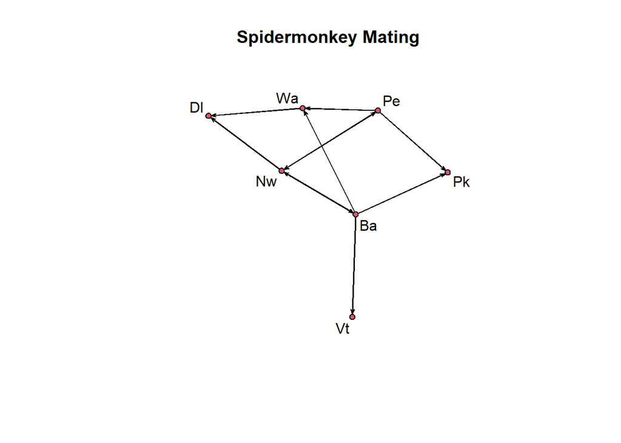

```r
#Mating Social Network:

mating_spmonkey <- spmonkey_el[spmonkey_el$Beh == "mating",] #making a separate data frame for mating
mating_spmonkey <- mating_spmonkey[,-c(2,4)] #removing unnecessary data. We will add back the "Mins" data as edge attributes later.
sp_mating_net <- as.network(mating_spmonkey, matrix.type = "edgelist", directed = TRUE, multiple = TRUE)
plot(sp_mating_net, label = "vertex.names", main="Spidermonkey Mating")
```

```r
#Let's add network and edge attributes to the network
sp_attr <- curl("https://raw.githubusercontent.com/nmerullo/AN588_BonoboSpitChain/main/spidermonkey_attributes.csv")
sp_attr <- read.csv(sp_attr)
head(sp_attr)
```

```
##   Number ID    sex   age dead.alive Repr_status
## 1      1 Pe female adult       dead   preg/lact
## 2      2 Ku female adult       dead   preg/lact
## 3      3 Dl female adult       dead   preg/lact
## 4      4 Ba female adult       dead   preg/lact
## 5      5 Vi female adult       dead   preg/lact
## 6      6 Nw   male adult      alive repr_active
```

```r
sp_mating_net %v% "sex" <- sp_attr$sex #adds sex as a node attribute
sp_mating_net %v% "age" <- sp_attr$age #adds age as a node attribute
sp_mating_net %v% "repr" <- sp_attr$Repr_status #adds reproductive status as a node attribute

#let's add the "Mins" from the initial spmonkey edgelist as edge weights
sp_mating_net %e% "time" <- spmonkey_el[spmonkey_el$Beh == "mating",]$Mins
```

This process can be repeated for grooming, play and contact networks.

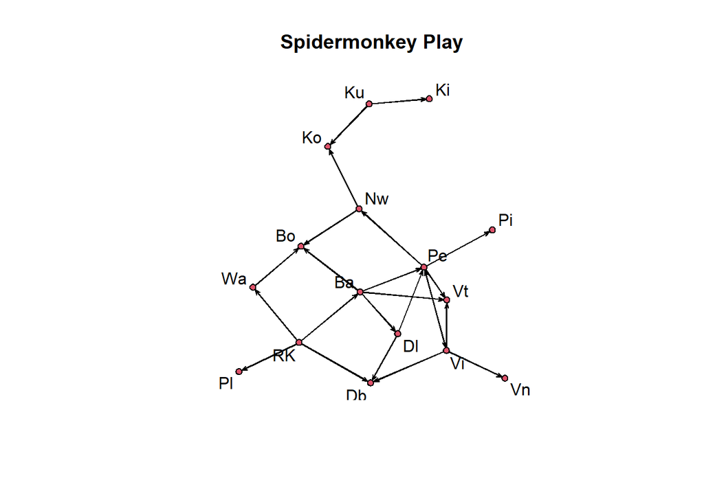

```r
play_spmonkey <- spmonkey_el[spmonkey_el$Beh == "play",][,-c(2,4)] #making a separate data frame for play behavior
sp_play_net <- as.network(play_spmonkey, matrix.type = "edgelist", directed = TRUE, multiple = TRUE)
plot(sp_play_net, label = "vertex.names", main="Spidermonkey Play")
```

```r
#Adding network and edge attributes to the network
sp_play_net %v% "sex" <- sp_attr$sex #adds sex as a node attribute
sp_play_net %v% "age" <- sp_attr$age #adds age as a node attribute
sp_play_net %v% "repr" <- sp_attr$Repr_status #adds reproductive status as a node attribute

#let's add the "Mins" from the initial spmonkey edgelist as edge weights
sp_play_net %e% "time" <- spmonkey_el[spmonkey_el$Beh == "play",]$Mins
```

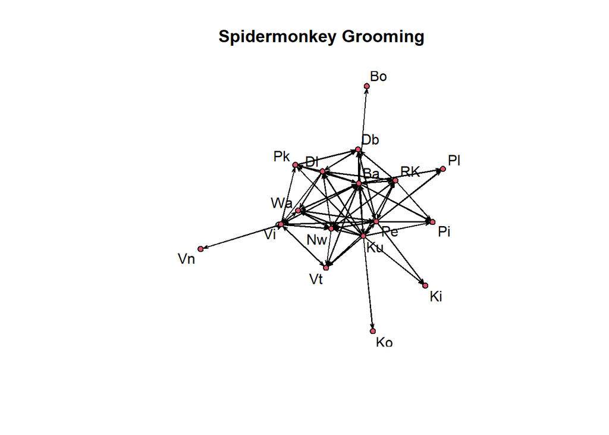

```r
groom_spmonkey <- spmonkey_el[spmonkey_el$Beh == "groom",][,-c(2,4)] #making a separate data frame for grooming behavior
sp_groom_net <- as.network(groom_spmonkey, matrix.type = "edgelist", directed = TRUE, multiple = TRUE, loops = TRUE)
plot(sp_groom_net, label = "vertex.names", main="Spidermonkey Grooming")
```

```r
#Adding network and edge attributes to the network
sp_groom_net %v% "sex" <- sp_attr$sex #adds sex as a node attribute
sp_groom_net %v% "age" <- sp_attr$age #adds age as a node attribute
sp_groom_net %v% "repr" <- sp_attr$Repr_status #adds reproductive status as a node attribute

#let's add the "Mins" from the initial spmonkey edgelist as edge weights
sp_groom_net %e% "time" <- spmonkey_el[spmonkey_el$Beh == "groom",]$Mins
```

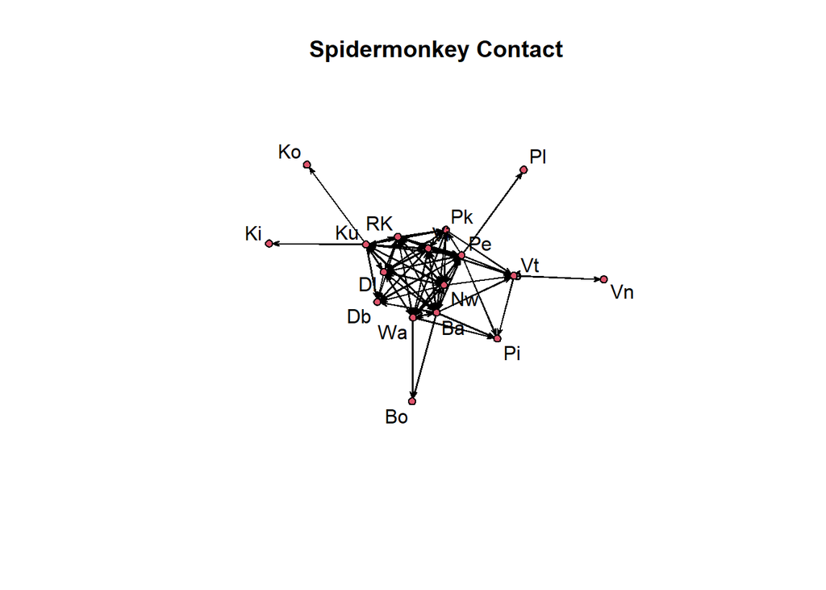

```r
contact_spmonkey <- spmonkey_el[spmonkey_el$Beh == "In contact",][,-c(2,4)] #making a separate data frame for contact
sp_contact_net <- as.network(contact_spmonkey, matrix.type = "edgelist", directed = TRUE, multiple = TRUE, loops = TRUE)
plot(sp_contact_net, label = "vertex.names", main="Spidermonkey Contact")
```

```r
#Adding network and edge attributes to the network
sp_contact_net %v% "sex" <- sp_attr$sex #adds sex as a node attribute
sp_contact_net %v% "age" <- sp_attr$age #adds age as a node attribute
sp_contact_net %v% "repr" <- sp_attr$Repr_status #adds reproductive status as a node attribute

#let's add the "Mins" from the initial spmonkey edgelist as edge weights
sp_contact_net %e% "time" <- spmonkey_el[spmonkey_el$Beh == "In contact",]$Mins
```